# Prosper Loan Data - Visualization slides

## Introduction

This project is on a data set from Prosper, which is America’s first marketplace lending platform, with over $7 billion in funded loans. This data set contains 113,937 loans with 81 variables on each loan, including loan amount, borrower rate (or interest rate), current loan status, borrower income, borrower employment status, borrower credit history, and the latest payment information.

The main purpose of this project is to summarize the characteristics of variables that can affect the loan status and to get some ideas about the relationships among multiple variables using summary statistics and data visualizations.

## Univariate Analysis

### 1. Analyze number of listings in each state

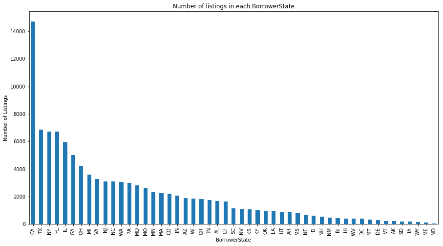

```python
# plots the bar graph
color = sb.color_palette()[0]

plt.figure(figsize=(15, 8))
states_count.plot(kind='bar', color=color);

plt.title('Number of listings in each BorrowerState');
plt.xlabel('BorrowerState');
plt.ylabel('Number of Listings');

plt.xticks(rotation=90);
```

#### Insights

The data says the highest listing counts in CA, TX, NY, FL and IL, which tracks with the rankings of top US states by population and the least in WY, ME, ND. In other words, the Prosper listings are distributed similarly to the population of the US.

### 2. The number of listings under each LoanStatus available

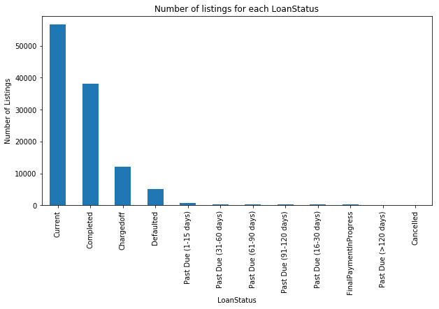

```python
# plots the bar graph for loan statuses

plt.figure(figsize=(10, 5))
status_count.plot(kind='bar', color=color);

plt.title('Number of listings for each LoanStatus');
plt.xlabel('LoanStatus');
plt.ylabel('Number of Listings');

plt.xticks(rotation=90);
```

#### Insights

The number of listings in each LoanStatus type are analyzed and the plot shows that Current status has got the highest number of listings followed by Completed and Chargedoff. Other statuses include dues for various intervals and cancelled whose frequency is too less

### 3. Income rate distribution of listings

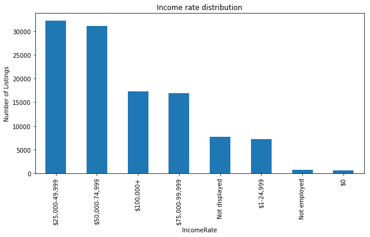

```python
# plots the bar graph for each income range specified

plt.figure(figsize=(10, 5))
income_range_count.plot(kind='bar', color=color);

plt.title('Income rate distribution');
plt.xlabel('IncomeRate');
plt.ylabel('Number of Listings');

plt.xticks(rotation=90);
```

## Bivariate Analysis

### 1. AvailableBankcardCredit vs. BorrowerRate

```
Text(0.5,1,'AvailableBankcardCredit vs. BorrowerRate')
```

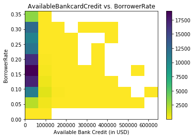

```python
# remove the null entries
loan_data_sub = loan_data.loc[loan_data.AvailableBankcardCredit.notnull()]

# plots the hist2d graph
plt.hist2d(data=loan_data_sub, x='AvailableBankcardCredit', y='BorrowerRate', cmap = 'viridis_r', cmin = 0.5);
plt.colorbar()

plt.xlabel('Available Bank Credit (in USD)')
plt.ylabel('BorrowerRate')
plt.title('AvailableBankcardCredit vs. BorrowerRate')
```

#### Insights

In this case, a hist2d plot is used because most of the listings have same range of bank card credit, there needs to be an intense segregation to see the diffusion between them and the plot says the more the amount in their bank card, the less the loans they take and less the borrower rate in most cases.

### 2. Income range vs ProsperPrincipalBorrowed

```
Text(0,0.5,'Prosper Principal Borrowed (in USD)')
```

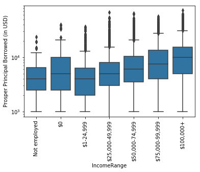

```python
# orders the x axis
order = ['Not employed', '$0', '$1-24,999', '$25,000-49,999', '$50,000-74,999', '$75,000-99,999', '$100,000+']

# plots the boxplot
sb.boxplot(data=loan_data, x='IncomeRange', y='ProsperPrincipalBorrowed', color=color, order=order);

# scale the y axis with log to analyze more accurately
plt.yscale('log')

plt.xticks(rotation=90);
plt.ylabel('Prosper Principal Borrowed (in USD)')
```

#### Insights

In this scenario, a boxplot is used to depict the results. The insights from the boxplot are the medians are in increasing order i.e., the more the income range the more the principal amount borrowed from the Prosper except for the not employed or 0 dollar salaried.

### 3. BorrowerRate pattern over years

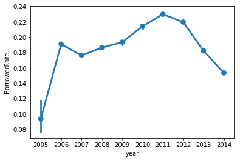

```python
# plots the pointplot for year vs BorrowerRate

sb.pointplot(data=loan_data, x='year', y='BorrowerRate');
```

#### Insights

Point plot is used to analyze this and it suites the analysis because this graph shows the nature of the variable from one xfactor to another. For this scenario, it shows that rate of interest increased from 2005-2006 and then fell off from 2006-2007 and then it constantly picked up for few years, reached its peak in 2011 which then started decreasing constantly.

## Mutlivariate Analysis

### Analyse how the BorrowerRate changed over years for Homeowners vs Non-Homeowners

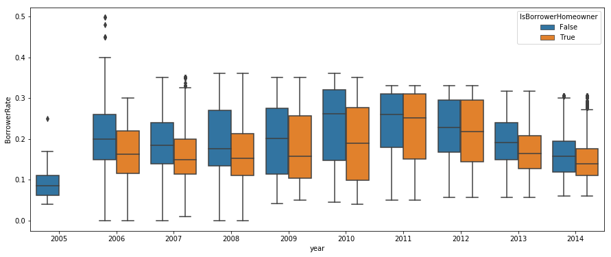

```python
# plots the boxplot to analyze homeowner's and non-homeowner's rate over years

g = sb.boxplot(data=loan_data, x='year', y='BorrowerRate', hue='IsBorrowerHomeowner');
g.figure.set_figwidth(15)
g.figure.set_figheight(6)
```